# PUBG 데이터를 활용한 EDA

### [참고 데이터](https://www.kaggle.com/c/pubg-finish-placement-prediction/data)

```python
import numpy as np
import pandas as pd
import seaborn as sns
import matplotlib.pyplot as plt
import warnings
warnings.filterwarnings('ignore')

from bokeh.io import output_notebook, show
from bokeh.models import ColumnDataSource
from bokeh.plotting import figure

output_notebook()
```

```python
df = pd.read_csv("./train_V2.csv")
```

```python
df.info()
```

```
<class 'pandas.core.frame.DataFrame'>
RangeIndex: 4446966 entries, 0 to 4446965
Data columns (total 29 columns):
 #   Column           Dtype
---  ------           -----
 0   Id               object
 1   groupId          object
 2   matchId          object
 3   assists          int64
 4   boosts           int64
 5   damageDealt      float64
 6   DBNOs            int64
 7   headshotKills    int64
 8   heals            int64
 9   killPlace        int64
```

[output cut: 21 more lines]

- DBNOs - Number of enemy players knocked.
- assists - Number of enemy players this player damaged that were killed by teammates.
- boosts - Number of boost items used.
- damageDealt - Total damage dealt. Note: Self inflicted damage is subtracted.
- headshotKills - Number of enemy players killed with headshots.
- heals - Number of healing items used.
- Id - Player’s Id
- killPlace - Ranking in match of number of enemy players killed.
- killPoints - Kills-based external ranking of player. (Think of this as an Elo ranking where only kills matter.) If there is a value other than -1 in rankPoints, then any 0 in killPoints should be - - - treated as a “None”.
- killStreaks - Max number of enemy players killed in a short amount of time.
- kills - Number of enemy players killed.
- longestKill - Longest distance between player and player killed at time of death. This may be - - - -- misleading, as downing a player and driving away may lead to a large longestKill stat.
- matchDuration - Duration of match in seconds.
- matchId - ID to identify match. There are no matches that are in both the training and testing set.
- matchType - String identifying the game mode that the data comes from. The standard modes are “solo”, “duo”, “squad”, “solo-fpp”, “duo-fpp”, and “squad-fpp”; other modes are from events or custom matches.
- rankPoints - Elo-like ranking of player. This ranking is inconsistent and is being deprecated in the - API’s next version, so use with caution. Value of -1 takes place of “None”.
- revives - Number of times this player revived teammates.
- rideDistance - Total distance traveled in vehicles measured in meters.
- roadKills - Number of kills while in a vehicle.
- swimDistance - Total distance traveled by swimming measured in meters.
- teamKills - Number of times this player killed a teammate.
- vehicleDestroys - Number of vehicles destroyed.
- walkDistance - Total distance traveled on foot measured in meters.
- weaponsAcquired - Number of weapons picked up.
- winPoints - Win-based external ranking of player. (Think of this as an Elo ranking where only winning matters.) If there is a value other than -1 in rankPoints, then any 0 in winPoints should be treated as a “None”.
- groupId - ID to identify a group within a match. If the same group of players plays in different - - - matches, they will have a different groupId each time.
- numGroups - Number of groups we have data for in the match.
- maxPlace - Worst placement we have data for in the match. This may not match with numGroups, as - sometimes the data skips over placements.
- winPlacePerc - The target of prediction. This is a percentile winning placement, where 1 corresponds to 1st place, and 0 corresponds to last place in the match. It is calculated off of maxPlace, not numGroups, so it is possible to have missing chunks in a match.

```python
df.head()
```

|  | Id | groupId | matchId | assists | boosts | damageDealt | DBNOs | headshotKills | heals | killPlace | ... | revives | rideDistance | roadKills | swimDistance | teamKills | vehicleDestroys | walkDistance | weaponsAcquired | winPoints | winPlacePerc |
| --- | --- | --- | --- | --- | --- | --- | --- | --- | --- | --- | --- | --- | --- | --- | --- | --- | --- | --- | --- | --- | --- |
| 0 | 7f96b2f878858a | 4d4b580de459be | a10357fd1a4a91 | 0 | 0 | 0.00 | 0 | 0 | 0 | 60 | ... | 0 | 0.0000 | 0 | 0.00 | 0 | 0 | 244.80 | 1 | 1466 | 0.4444 |
| 1 | eef90569b9d03c | 684d5656442f9e | aeb375fc57110c | 0 | 0 | 91.47 | 0 | 0 | 0 | 57 | ... | 0 | 0.0045 | 0 | 11.04 | 0 | 0 | 1434.00 | 5 | 0 | 0.6400 |
| 2 | 1eaf90ac73de72 | 6a4a42c3245a74 | 110163d8bb94ae | 1 | 0 | 68.00 | 0 | 0 | 0 | 47 | ... | 0 | 0.0000 | 0 | 0.00 | 0 | 0 | 161.80 | 2 | 0 | 0.7755 |
| 3 | 4616d365dd2853 | a930a9c79cd721 | f1f1f4ef412d7e | 0 | 0 | 32.90 | 0 | 0 | 0 | 75 | ... | 0 | 0.0000 | 0 | 0.00 | 0 | 0 | 202.70 | 3 | 0 | 0.1667 |
| 4 | 315c96c26c9aac | de04010b3458dd | 6dc8ff871e21e6 | 0 | 0 | 100.00 | 0 | 0 | 0 | 45 | ... | 0 | 0.0000 | 0 | 0.00 | 0 | 0 | 49.75 | 2 | 0 | 0.1875 |

5 rows × 29 columns

```python
print("평균 킬 : {:.4f}, 99퍼센트의 플레이어 킬 : {} 이하, 가장 많은 킬 수 : {}.".format(df['kills'].mean(),df['kills'].quantile(0.99), df['kills'].max()))
```

```
평균 킬 : 0.9248, 99퍼센트의 플레이어 킬 : 7.0 이하, 가장 많은 킬 수 : 72.
```

킬 수 그래프 -> 1킬만 해도 평균보다 잘하는 축에 속한다.

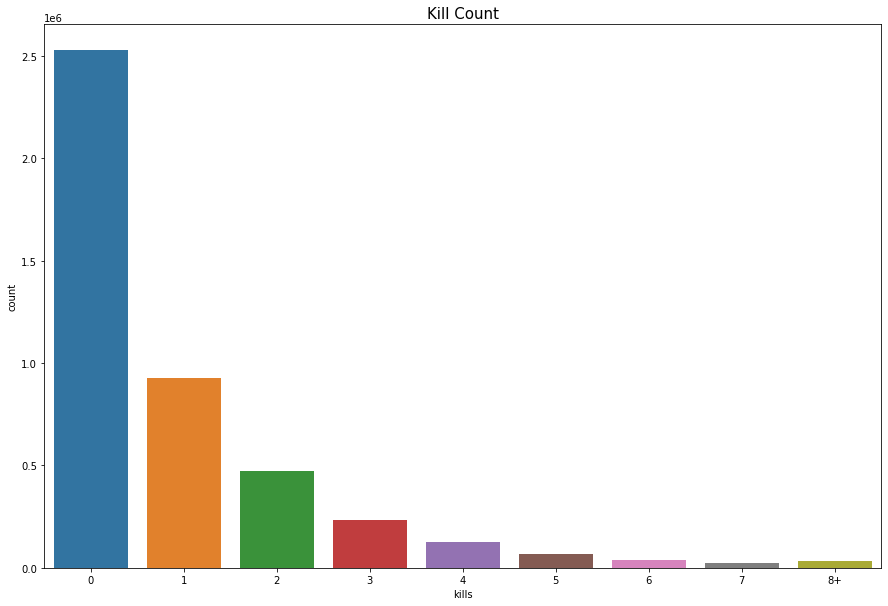

```python
data = df.copy()
data.loc[data['kills'] > data['kills'].quantile(0.99)] = '8+'
plt.figure(figsize=(15,10))
sns.countplot(data['kills'].astype('str').sort_values())
plt.title("Kill Count",fontsize=15)
plt.show()
```

0킬한 사람들의 데미지 그래프 -> 대부분 데미지도 못넣고 죽음.

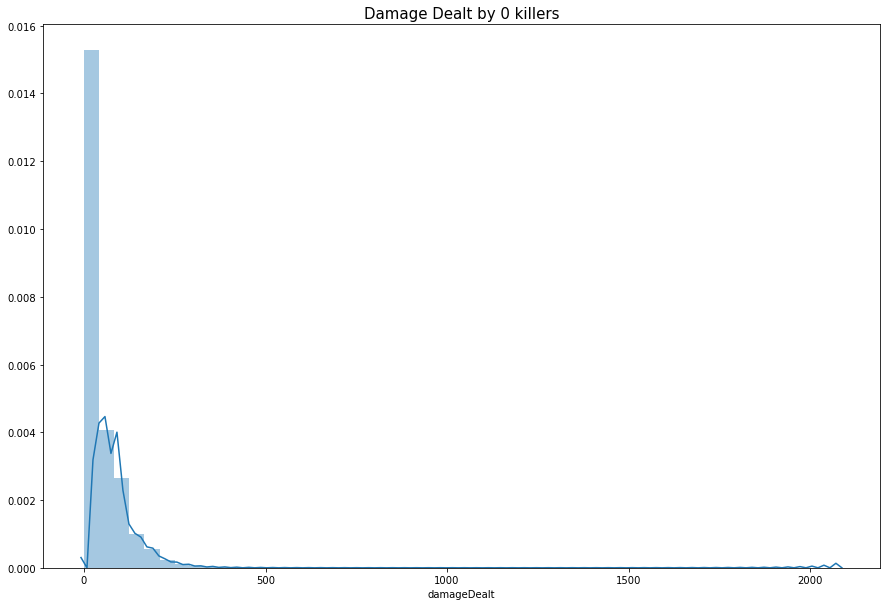

```python
data = df.copy()
data = data[data['kills']==0]
plt.figure(figsize=(15,10))
plt.title("Damage Dealt by 0 killers",fontsize=15)
sns.distplot(data['damageDealt'])
plt.show()
```

```python
print("0킬로 우승한 플레이어 수 : {} ({:.4f}%) ".format(len(data[data['winPlacePerc']==1]), 100*len(data[data['winPlacePerc']==1])/len(df)))

data1 = df[df['damageDealt'] == 0].copy()
print("데미지0으로 우승한 플레이어 수 {}  ({:.4f}%) ".format(len(data1[data1['winPlacePerc']==1]), 100*len(data1[data1['winPlacePerc']==1])/len(df)))
```

```
0킬로 우승한 플레이어 수 : 16666 (0.3748%)
데미지0으로 우승한 플레이어 수 4770  (0.1073%)
```

킬과 우승의 관계 그래프 -> 킬이 많을수록 우승 확률이 높다.

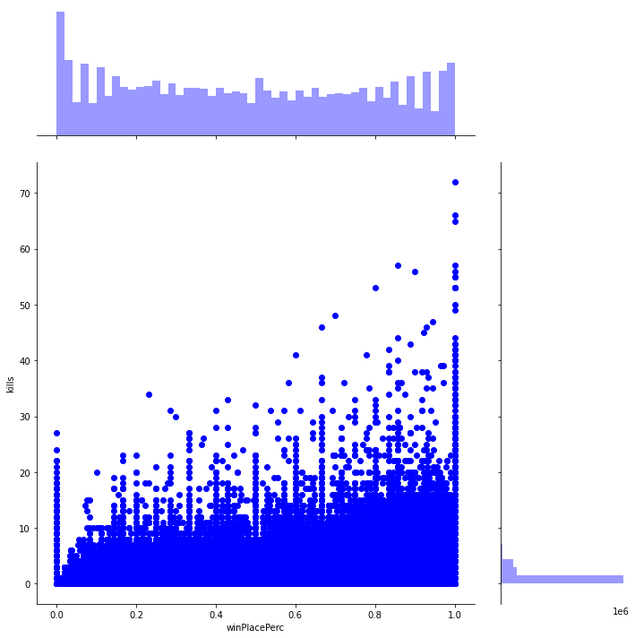

```python
sns.jointplot(x="winPlacePerc", y="kills", data=df, height=10, ratio=3, color="b")
plt.show()
```

킬수별 그룹화 후 우승의 관계 그래프

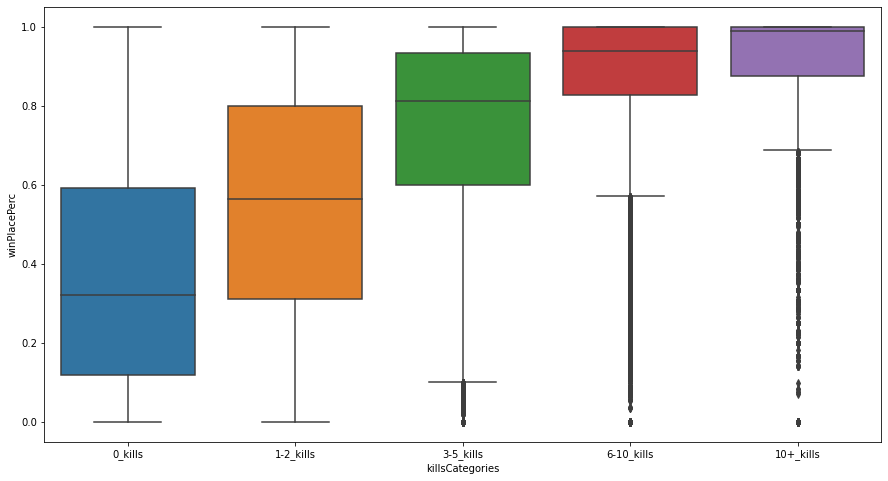

```python
kills = df.copy()

kills['killsCategories'] = pd.cut(kills['kills'], [-1, 0, 2, 5, 10, 60], labels=['0_kills','1-2_kills', '3-5_kills', '6-10_kills', '10+_kills'])

plt.figure(figsize=(15,8))
sns.boxplot(x="killsCategories", y="winPlacePerc", data=kills)
plt.show()
```

```python
print("평균 플레이어의 걸은 거리 {:.1f}m, 플레이어의 99프로가 걸은 거리{}m 이하, 가장 많이 걸은 거리 {}m.".format(df['walkDistance'].mean(), df['walkDistance'].quantile(0.99), df['walkDistance'].max()))
```

```
평균 플레이어의 걸은 거리 1154.2m, 플레이어의 99프로가 걸은 거리4396.0m 이하, 가장 많이 걸은 거리 25780.0m.
```

99퍼센트 플레이어가 걸은 거리 이하로 걸은 플레이어의 분포

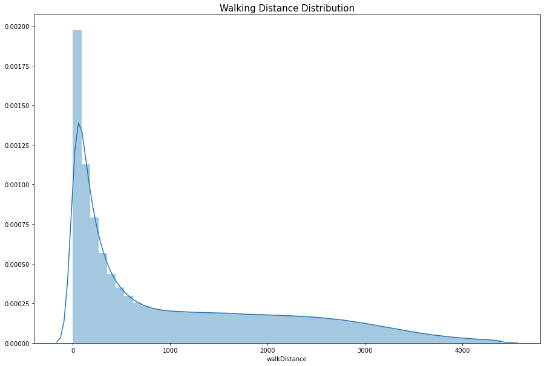

```python
data = df.copy()
data = data[data['walkDistance'] < df['walkDistance'].quantile(0.99)]
plt.figure(figsize=(15,10))
plt.title("Walking Distance Distribution",fontsize=15)
sns.distplot(data['walkDistance'])
plt.show()
```

99퍼센트 플레이어가 걸은 거리 이상으로 걸은 플레이어의 분포

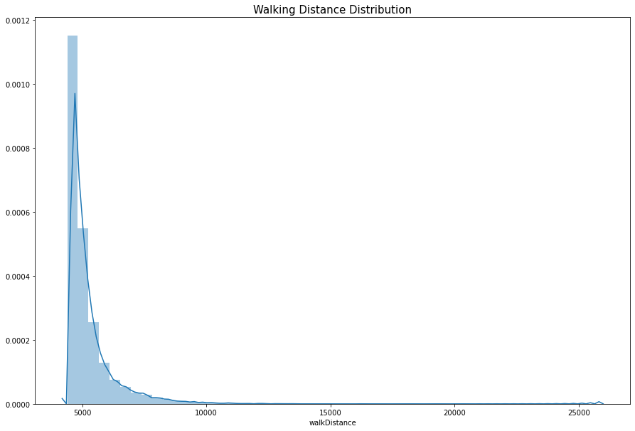

```python
data = df.copy()
data = data[data['walkDistance'] > df['walkDistance'].quantile(0.99)]
plt.figure(figsize=(15,10))
plt.title("Walking Distance Distribution",fontsize=15)
sns.distplot(data['walkDistance'])
plt.show()
```

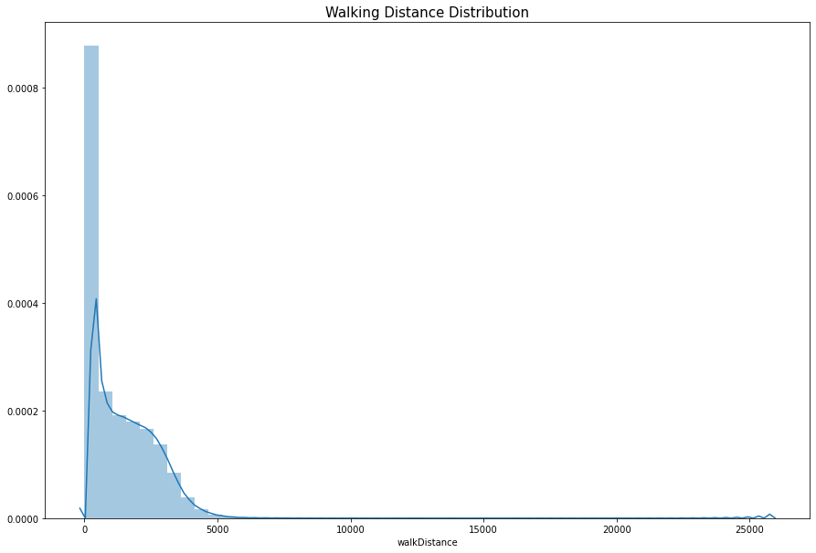

```python
data = df.copy()
plt.figure(figsize=(15,10))
plt.title("Walking Distance Distribution",fontsize=15)
sns.distplot(data['walkDistance'])
plt.show()
```

잠수 or 팅김으로 죽은 플레이어의 수

```python
print("걷지도 않은 플레이어의 수 : {}  ({:.4f}%)".format(len(data[data['walkDistance'] == 0]), 100*len(data1[data1['walkDistance']==0])/len(df)))
```

```
걷지도 않은 플레이어의 수 : 99603  (2.0329%)
```

걸은 거리와 우승과의 관계 그래프 -> 걸은 거리가 많을수록 우승 확률이 높다?!

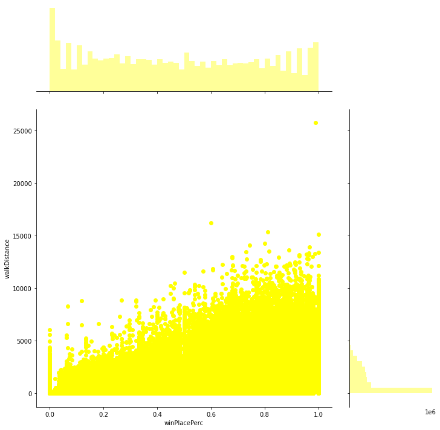

```python
sns.jointplot(x="winPlacePerc", y="walkDistance",  data=df, height=10, ratio=3, color="yellow")
plt.show()
```

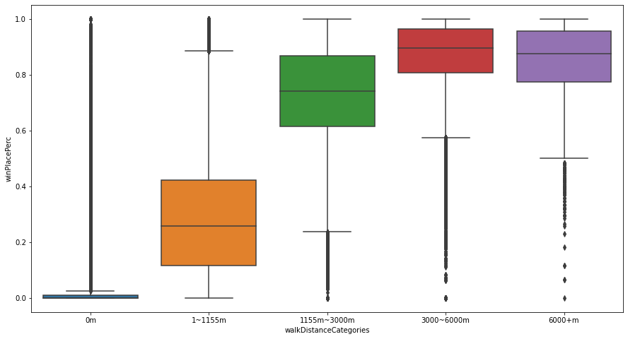

```python
walkDistance = df.copy()

walkDistance['walkDistanceCategories'] = pd.cut(walkDistance['walkDistance'], [-1, 0, 1155, 3000, 6000, 25001], labels=['0m','1~1155m', '1155m~3000m', '3000~6000m', '6000+m'])

plt.figure(figsize=(15,8))
sns.boxplot(x="walkDistanceCategories", y="winPlacePerc", data=walkDistance)
plt.show()
```

```python
# df = df.copy()
# df.loc[df['kills'] > df['kills'].quantile(0.99)] = '8+'


# temp = df['kills'].astype('str').value_counts().sort_index()
# y = temp.tolist()
# x = temp.index.tolist()

# print(x)
# print(y)
# # df['kills'].value_counts().index
# # df['kills'].astype('str').sort_values()

# from bokeh.plotting import figure
# from bokeh.io import output_file, show
# output_file("bar.html")

# df = train.copy()
# df.loc[df['kills'] > df['kills'].quantile(0.99)] = '8+'
# temp = df['kills'].astype('str').value_counts().sort_index()
# y = temp.tolist()
# x = temp.index.tolist()

# p = figure(x_range=x, y_range=(0, 3000000))
# p.vbar(x = x, top= y)
# show(p)
# p = figure(plot_width=700, plot_height=400, x_axis_type = "kill count")
# sns.countplot(data['kills'].astype('str').sort_values())
# plt.title("Kill Count",fontsize=15)
```